# Omic Evidence of Carbon Transformation from the Organic to Mineral Horizon

Hanna Choi

hanchoi@umass.edu

May 12, 2021

```r
library(knitr)
opts_chunk$set(fig.align = "center")
library(readr)
library(tidyverse)
library(ggplot2)
library(ggpubr)
library(readxl)
library(DT)
```

# Abstract

##### Keywords: Metabolomics, Lipidomics, Terrestrial Soil, Heat Treatment

# Introduction

The projected course of climate change indicates an increase in temperature of up to 5 degrees Celsius by 2100.<sup>1</sup> It is an immediate risk to all environments including terrestrial soil, home to a diverse range of microorganisms that are yet to be fully discovered due to technological limitations.<sup>2</sup> Thus far, an increase in temperature by 5 degrees Celsius has been found to alter terrestrial soil microbial diversity and abundance in both horizons, Organic and Mineral, according to the longitudinal study performed at the Harvard Forest since 1991.<sup>3</sup>

The terrestrial plots in the Harvard Forest have undergone continuous heat treamtent since 1991 using wire coils and have continuously been monitored.<sup>3–5</sup> Samples extracted in 2008 indicated a negative relation between mean annual temperature and root respiration.<sup>6</sup> The authors concluded the lowered metabolic activity (aka root respiration rate) could be due to either decreases in metabolic capacity or moisture levels.<sup>6</sup> Harvard Forest analyses also indicated a negative relation between increased temperature and carbon use efficiency which is due to the increasing energy cost of maintaining existing biomass.<sup>7</sup> By 2011, after 20 years of heat treatment, there was a significant alteration to the microbial diversity within the Organic horizon, specifically the individual members of the Actinobacteria, Alphaproteobacteria and Acidobacteria.<sup>5</sup> The bacterial communities began to resemble mineral soils and was strongly driven by decreased abundance of a few dominant taxa.<sup>5</sup>

FTICR-MS data from 2017 samples indicated a transformation of carbon from the organic to the mineral horizon with carbon abundance decreasing by 13% in the organic horizon and increasing by 17% in the mineral horizon.<sup>3</sup> Metatranscriptomic data of the mineral horizon indicated a shift in diversity with an increase in Actinobacteria, Ktedonobacteria, and Alphaproteobaceria along with a decrease in acidobacteria, Betaproteobacteria, Gammaproteobacteria, Leotiomycetes (FDR<0.1), and Agaricomycetes (FDR<0.1).<sup>3</sup> The organic horizon similarly indicated a statistically significant (FDR<0.1) increase in Actinobacteria, Thermoleophilia, and Ktedonobacteria along with a statistically significant (FDR<0.1) decrease in Leotiomycetes, Sordariomycetes, and Agaricomycetes.<sup>3</sup>

Metabolomics holds potential in supplementing the identified differential levels of carbon compounds and diversity and may help in understanding the possible decrease in metabolic activity and efficiency within these extremely inaccessible micro-environments. As a research assistant within the Blanchard Laboratory, I had the opportunity to analyze the 2017 metabolomic and lipidomic data. As a result, it was necessary, as a researcher, to understand the context of the metabolomic data. This thesis therefore aims to understand the field of metabolomics and to uncover the compounds affected by heating in the terrestrial soil in 2017. Unconventionally, the manuscript will include R code utilized for statistical analysis and visualization.

## Literature Review

A literature review on metabolomics was performed on the 14 free full text articles published within the last five years based on a Pubmed search of [“Non-targeted metabolomics soil NOT gut”](https://pubmed.ncbi.nlm.nih.gov/?term=Non-targeted+metabolomics+soil+NOT+gut&filter=simsearch2.ffrft). A literature review on lipidomics was additionally performed on the 18 free full text articles published with the last five years based on a Pubmed search of [“lipidomics soil”](https://pubmed.ncbi.nlm.nih.gov/?term=lipidomics+soil&filter=simsearch2.ffrft&filter=years.2016-2021). Additional articles referenced by these full texts were reviewed.

### Omics

The field of omics consists of the well understood study of genomics and transcriptomics as well as the less understood study of proteomics and metabolomics (Figure 1).<sup>8,9</sup> Integrative omic approaches have proven to be beneficial in aquatic settings and human disease<sup>10,11</sup> and is increasing in popularity in soil environments, the most complex microbial system known to date.<sup>9</sup>

Metabolomics can further be subclassified, based on metabolite properties, into metallomics, lipidomics, and polar metabolomics.<sup>8</sup> Metabolomics in ecology is not well understood due to the difficulty of metabolite extraction from entire communities, like terrestrial soil, compared to single organisms like human and bacteria as an entire community logically contains an exponentially larger set of diverse metabolites compared to single organisms.<sup>8</sup> Nonetheless, recent efforts have been made to improve the extraction, analysis, and incorporation of metabolomics into the understanding of the complex biomolecular functions within entire communities.<sup>12,13</sup> Different extraction methods include liquid chromatography and gas chormatography as well as continuous flow isotope ratio and isoprime with analysis via mass spectrometry.<sup>3,14</sup> DIfferent extraction methods result in different metabolite profiles, thus, methodology is a significant confounder in studies that aim to identify biomarkers or differential levels of metabolic activity.<sup>12</sup>

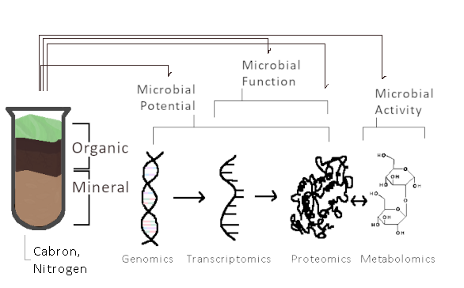

### Non-targeted Metabolomics

Non-targeted metabolomics is a useful analytical tool to understand metabolite profiles of species such as plants and animals.<sup>15–18</sup> Additionally, and arguably more importantly, non-targeted metabolomics helps identify biochemical mechanisms within species or environments such as plants and bacteria that play significant roles in pathogen response and adaptation to external changes within the rhizosphere, the narrow region of soil that is directly affected by root exudation<sup>12,13,19</sup> and in varying substrates like clay, sand, soil, and “farm 4 soil” conditioned soil.<sup>12,20</sup> For example, ultra-high performance liquid chromatography (UHPLC) of pathogen-inoculated *Sorghum bicolor* primed with growth-promoting rhizobacteria enhanced levels of amino acids (tyrosine, tryptophan), phytohormones (jasmonic acid and salicylic acid conjugates, and zeatin), and defence-related components of the lipidome.<sup>21</sup> Non-targeted gas chromatography-time-of-flight mass spectrometry within the rhizosphere of Cadmium-stressed *Sedum plumbizincicola* identified 33 differentially expressed metabolites.<sup>22</sup> Cadmium stress inhibited the secretion of malic acid, glycolic acid, glutaric acid, and other organic acids in the roots of *S. plumbizincicola* which indicates that the stress may reduce organic acid release in roots to reduce the activation of Cadmium, thereby reducing the dissolution, absorption, and transport of Cadmium in plant tissues and reducing the damage to the plants.<sup>22</sup> Continuous flow isotope ratio mass spectrometry and isoprime mass spectrometry within Citruses inoculated with pathogen *Alternaria alternata* identified a metabolite profile change of 200 metabolites mostly related to the mevalonic and liolenic pathways as well as localization of hexanoic acid to the roots which supports signs of pathogen resistance.<sup>14</sup> Hydrophilic interaction liquid chromatography (HILIC)–mass spectrometrywithin enriched farming soil compared to control soil indicated antimicrobial properties within this conditioned medium.<sup>20</sup> Of the 7 significant metabolites identified, tryptamine, and 2-hydroxyisocaproic acid indicated antimicrobial activity.<sup>20</sup> Non-targeted ultra-high-performance liquid chromatography quadrupole time-of-flight mass spectrometry within tomato plants inoculated with *P. capisici* revealed a well-documented phytohormone responsible for resistance induction following pathogen infection, salicylic acid, and its volatile derivative methyl salicylic acid, were more abundant in the stem and leaf after pathogen inoculation.<sup>19</sup> In hypoxic conditions, *Suaeda maritima*, a halophyte found in wetlands, showed an increased level of tricarboxylic acid (TCA)-cycle intermediates such as succinate, malate and citrate based on analysis of high-performance liquid chromatography and H-NMR spectra.<sup>17</sup>

In a study on crop quality that utilized metabolomics and genomics, the obstacle-group of ramie (Boehmeria nivea L. Gaud) showed decreased levels of *Rhizobiaceae* (commonly indicative of plant elongation), *Lysobacter antibioticus* (commonly indicative of plant defense), and *Bradyrhizobium japonicum* as well as increased levels of *Azospirillum lipoferum* and *A. brasilense*. Gas chromatography mass spectrometery identified differential levels of cysteinylglycine (Cys-Gly), uracil, malonate, and glycerol.<sup>23</sup> These findings indicate an inhibition of IAA, an auxin that promotes plant elongation, and decreased plant defense because the metabolites identified are speculated to be mediators for *L. antibioticus*.<sup>23</sup>

non-targeted reversed-phase ultraperformance liquid chromatography electrospray ionization quadrupole-time-of-flight mass spectrometry indicated phosphate deficiency depleted metabolite abundance in the rhizosphere, indicating P5-type ATPase, which utilizes phosphate, is affected.<sup>24</sup>

### Developing Lipidomics

Lipidomic analyses, similar to other metabolomic analyses mentioned previously, are helpeful methods for biomarker identification in species including humans<sup>25</sup> and other animals as well as plants and microbes.<sup>9,26</sup> Lipid variations within chain length, side chain composition, and degree of saturation are important identifiers of lipids, and due to the amount of variability, extraction and identification is extremely difficult, which is the reason behind the field of lipidomics being technologically behind compared to genomics and metabolomics.<sup>27</sup> Recent literature, therefore focuses on improving lipid extraction and analysis methods rather than application and comprehension.<sup>27</sup> For example, a 2019 lipidomics methodology of using the combination of hydrophilic interaction and C30 reversed-phase chromatography with mass spectrometry improved the resolution of the isomers of corn roots as well as identification of acylphosphatidylglycerol in corn roots for the first time.<sup>27</sup> Liquid chromatography tandem mass spectrometry identified over 500 lipids and 18 lipid classes and their differential levels within various tissue types inoculated with the procine parasite, *Ascaris suum*.<sup>26</sup>

The classes of lipids are the following: fatty acyls (FA), glycerlipids (GL), glycerophospholipids (GP), Sphingolipids (SP), Sterol Lipids (ST), and Prenol Lipids (PR).<sup>28</sup>

# Methods

## Metabolite Extraction

The metabolomes of the Harvard Forest soil samples were analyzed as described previously.<sup>3</sup> Briefly, metabolites were extracted with MPLEx protocol by adding solvent mixture (chloroform and methanol) to the ten grams of soil sample with nanopure water amended. After the extraction, aqueous layer liquid was transferred to a new glass vial. They were completely dried in a Speed-Vac concentrator (CentriVap, LABCONCO, Kansas City, MO) and chemically derivatized for GC-MS analysis using Agilent 7890A gas chromatograph coupled with a 5957C mass spectrometer (Agilent Technologies, Inc. Santa Clara, CA). All the samples were analyzed within 24 hr after derivatization. The processing order was randomized both for the derivatization and the GC-MS analysis. All the collected mass spectrometer data files were converted to netCDF format and processed using Metabolite Detector.<sup>29</sup> All the peaks were matched to PNNL’s augmented version of metabolomics database, which has retention index and fragmented spectra of metabolites and additionally cross-checked with NIST17 GC-MS spectral database.<sup>30</sup> Identification of detected metabolites was validated manually to avoid misidentification of metabolites or false positive and negative errors.

## Lipid Extraction

For untargeted lipidomic analyses, the lipids extracted were reconstituted in methanol prior to analysis using liquid chromatography tandem mass spectrometry (LC-MS/MS), as previously described (PMID: 28158427). Briefly, a Waters Acquity UPLC H class system interfaced with a Velos-ETD Orbitrap mass spectrometer was used for LC-MS/MS analyses. 10 μl of reconstituted sample was injected onto a Waters CSH column (3.0 mm x 150 mm x 1.7 μm particle size) and separated over a 34-minute gradient (mobile phase A: ACN/H2O (40:60) containing 10 mM ammonium acetate; mobile phase B: ACN/IPA (10:90) containing 10 mM ammonium acetate) at a flow rate of 250 μl/minute. Eluting lipids were introduced to the MS via electrospray ionization in both positive and negative modes, and lipids were fragmented using higher-energy collision dissociation (HCD) and collision-induced dissociation (CID) (PMID: 28158427). Lipids will be identified using the software LIQUID (PMID: 28158427). Each identification was manually validated by examining the MS/MS spectra for fragments that match the identified lipid including diagnostic ions as well as associated chains. The isotopic profile, extracted ion chromatogram, mass measurement error, and elution time are also examined for high level confidence in the identification. All raw mass spectrometry data set files were aligned and gap-fill using the identified lipid name, observed m/z, and the retention time from each analysis. This is achieved by aligning all datasets (grouped by ionization type) and matching unidentified features to their identified counterparts using MZmine2 (PMID: 20650010). Aligned features were manually verified and peak intensity values exported for statistical analysis.

## Identification and Statistical Analysis

The Kyoto Encyclopedia of Genes and Genomes (KEGG), a set of accessible online databases that encompasses a broad range of genes, genomes, pathways, and metabolites consist of compounds, metabolites and lipids, by class and subclass (Kanehisa, 2000). Metabolites and Lipids were matched to the KEGG database using the R packages KEGGREST from Bioconductor, an open access bioinformatics software, and KEGGdata, a JGS internal R package.

Data was then normalized by median and log transformed (tidyverse), statistically analyzed via t-test (p< 0.05) (base R), and visualized (ggplot and ggpubr) to understand the overall trend of lipid and metabolite abundance. MetaboAnalyst 5.0 statistical analysis was utilized to visualize Self-organizing map (SOM) clustering and K-means concordance plots of the data normalized by median, log transformed, and was auto-scaled with mean-centering and dividing by the standard deviation of each plot.

## Metabolite Mapping

Metabolites were mapped as networks by horizon using the MetScape Pearson Correlation Calculator designed for metabolomic data, in which medians were used for fold change to account for possible outliers. The correlations were then mapped in Cytoscape.

# Results

## Metabolome

| Table 1. Metabolites | M_C_4_AB | M_C_7_AB | M_C_12_AB | M_C_14_AB | M_C_19_AB | M_C_30_AB | M_H_2_AB | M_H_2B | M_H_4_AB | M_H_11_AB | M_H_17_AB | M_H_26_AB | M_H_28_AB | M_H_30_AB | M_H_32_AB | M_H_34_AB | O_C_4_AB | O_C_12_AB | O_C_14_AB | O_C_19_AB | O_C_27_AB | O_C_34_AB | O_H_2_AB | O_H_4_AB | O_H_11_AB | O_H_17_AB | O_H_32_AB |
| --- | --- | --- | --- | --- | --- | --- | --- | --- | --- | --- | --- | --- | --- | --- | --- | --- | --- | --- | --- | --- | --- | --- | --- | --- | --- | --- | --- |
| 1,3-dihydroxyacetone | 201558.12 | 230863.37 | 3.109100e+05 | 245659.16 | 232123.15 | 264868.29 | 132565.89 | 175407.99 | 207265.64 | 200195.19 | 11486398.85 | 3.319451e+05 | 1.867908e+05 | 3.739364e+05 | 3.009051e+05 | 371204.09 | 313388.40 | 411931.82 | 246935.79 | 2.703669e+05 | 624569.86 | 327319.97 | 233960.17 | 222957.71 | 186341.81 | 234212.59 | 177300.88 |
| 1,4-D-xylobiose | 92632.29 | 59878.84 | 4.440647e+05 | 204729.05 | 140847.53 | 226858.20 | 77650.67 | 68907.67 | 87523.20 | 122632.20 | 71585.26 | 1.244069e+05 | 4.958419e+04 | 3.571785e+05 | 3.700818e+05 | 46574.97 | 161702.96 | 501460.96 | 119733.01 | 3.389600e+05 | 247569.78 | 310476.96 | 139770.79 | 181227.11 | 53837.28 | 166420.54 | 33521.09 |
| 2-furoic acid | 0.00 | 20244.87 | 3.686187e+05 | 290832.04 | 346959.55 | 362864.05 | 190631.44 | 22918.11 | 419948.52 | 136766.67 | 208463.48 | 2.751251e+05 | 3.562639e+05 | 4.443482e+05 | 3.718055e+04 | 359615.87 | 216406.20 | 290985.89 | 164079.90 | 2.745173e+04 | 250931.93 | 226323.60 | 143294.09 | 167878.78 | 12033.36 | 10321.09 | 141094.85 |
| 2-hydroxypyridine | 848669.07 | 1503773.77 | 1.530763e+06 | 1166233.20 | 1366151.36 | 1244331.73 | 1088860.72 | 2088375.45 | 1089495.38 | 1016476.22 | 1145739.35 | 1.217879e+06 | 1.069385e+06 | 1.578411e+06 | 1.171211e+06 | 1377519.98 | 1267011.05 | 2058137.27 | 857639.30 | 1.564932e+06 | 1273704.63 | 1205659.17 | 1572751.26 | 1247938.85 | 1663712.83 | 986499.73 | 1165535.34 |
| 3-amino-2-piperidone* | 338073.02 | 330988.69 | 7.234261e+05 | 1008494.02 | 735189.59 | 708869.67 | 338854.89 | 586736.42 | 271465.47 | 594404.14 | 239338.97 | 2.289173e+05 | 1.794624e+05 | 2.062348e+05 | 3.923544e+05 | 306326.93 | 7166777.68 | 14202079.92 | 4490234.22 | 1.934625e+06 | 5710184.79 | 5986927.46 | 4191278.31 | 3139169.48 | 1357579.16 | 1841770.59 | 1167193.62 |
| 3-hydroxybutyric acid | 665167.99 | 968540.97 | 1.950631e+06 | 1364056.89 | 645910.97 | 1745759.09 | 523484.96 | 492646.14 | 491344.61 | 484619.48 | 1347377.80 | 8.859267e+05 | 1.517862e+06 | 1.634423e+06 | 1.299327e+06 | 2993634.73 | 654375.27 | 452154.62 | 803181.99 | 6.724682e+05 | 550734.51 | 1259458.16 | 387054.82 | 544096.20 | 316679.06 | 413058.79 | 468887.38 |
| 4-aminobutyric acid (GABA) | 1219404.69 | 9283552.66 | 4.657182e+06 | 4822063.87 | 4692235.04 | 3085062.22 | 629202.45 | 1072926.28 | 2002605.01 | 3365820.52 | 1738429.01 | 0.000000e+00 | 9.918991e+05 | 2.202431e+06 | 4.814624e+06 | 1817006.12 | 18276546.29 | 28283192.04 | 26770327.96 | 1.830929e+07 | 16636634.93 | 11400763.42 | 10788979.77 | 14357431.63 | 10690717.18 | 6293252.57 | 1923468.54 |
| adenosine | 597430.58 | 2618724.94 | 9.863536e+05 | 1479949.19 | 874531.50 | 1078726.70 | 1835680.09 | 1057495.90 | 771983.72 | 1501351.89 | 1954308.17 | 1.421325e+06 | 2.240124e+06 | 1.481245e+06 | 1.718898e+06 | 4543631.11 | 700306.96 | 288475.03 | 611427.68 | 6.537055e+05 | 451518.50 | 1051869.94 | 794504.19 | 1041657.32 | 630165.16 | 1367511.19 | 57984.65 |
| allantoin | 1503819.03 | 550998.29 | 6.396947e+03 | 2210454.92 | 22046.00 | 93163.24 | 14199.32 | 589931.81 | 915507.76 | 2369091.66 | 676963.71 | 4.834321e+05 | 4.529234e+04 | 2.787000e+04 | 8.849445e+03 | 1244739.09 | 12636166.36 | 10877713.49 | 3046188.25 | 7.266656e+06 | 3009841.17 | 14321494.31 | 6961787.96 | 6299574.88 | 2915223.54 | 18380042.24 | 1755759.47 |
| arbutin | 610194.30 | 0.00 | 1.900044e+05 | 3361765.77 | 3250395.94 | 3068598.22 | 0.00 | 1739594.83 | 0.00 | 249393.76 | 0.00 | 4.559998e+06 | 0.000000e+00 | 9.985208e+05 | 4.013851e+05 | 5327529.21 | 1460283.22 | 1313422.72 | 2125967.01 | 4.871846e+06 | 16196.79 | 2867365.10 | 49558.32 | 414079.19 | 0.00 | 0.00 | 0.00 |

[output cut: 201 more lines]

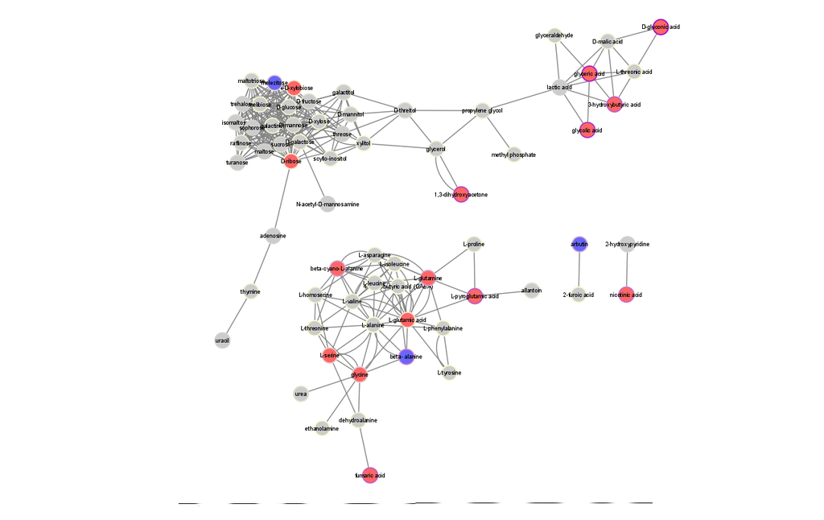

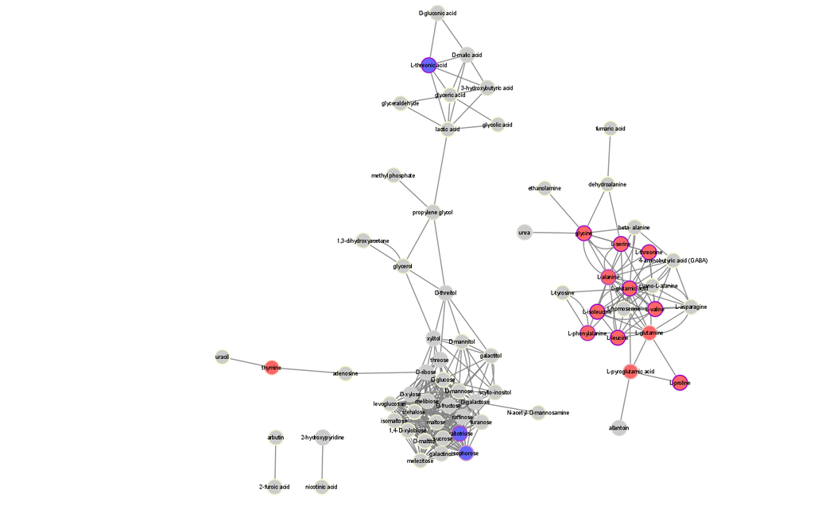

**Figure 2. Mapped metabolites of the (top) Organic and (bottom) Mineral Horizons.** Downward fold changes are blue and upward fold chages are red. Statistically significant metabolites (p-value < 0.05) are indicated with purple outlines with more prominently purple outlines being more significant.

```r
# using ggplot2 and dplyr to display all 211 in both treatments within both horizons
## Import data
metabs <- read_csv("Tables/metabolite_all_pvalues_foldchange_KEGG.csv")[,-c(1,4:8)] %>%
  mutate(metabplot = gsub(".*_", "", metabplot))
```

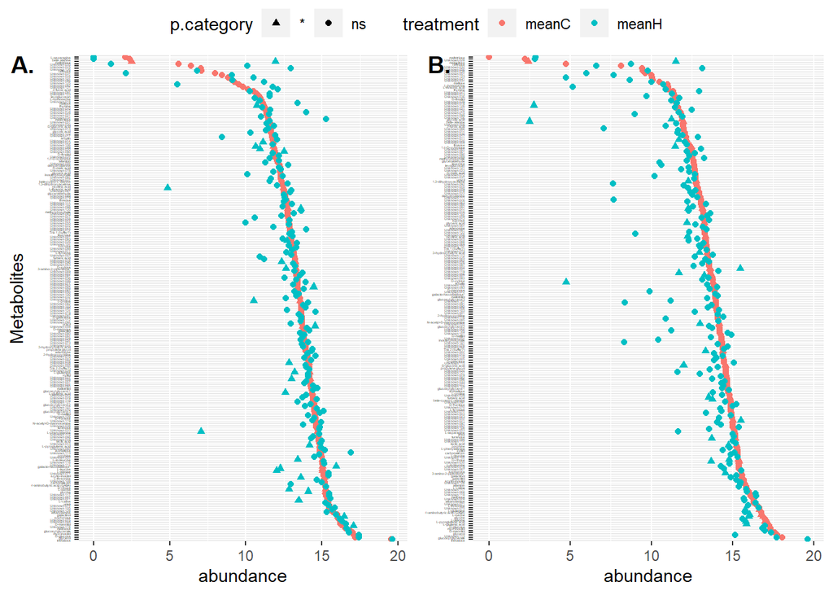

**Figure 3. Metabolites in heated and controled treamtents in both horizons.** Metabolomic data indicate a differential abundance between the heated and control groups within the (A) Mineral and (B) Organic horizons. Significant metabolites (p-value < 0.05) are indicated by triangles.

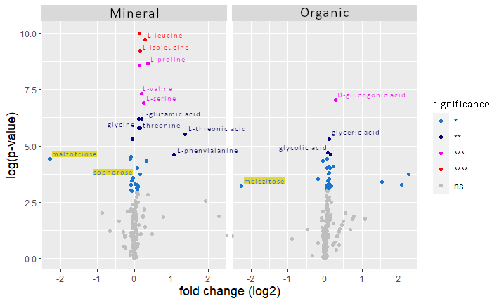

**Figure 4. Log2 Fold Change of All Unique Metabolites.** Metabolomic extraction and analysis resulted in 211 unique metabolites within the Mineral (left) and Organic (right) horizon. (P-values < 0.001 = “***”, P-values < 0.01 = “**”, P-values < 0.05 =“*”)

```r
## Factors for ggplot with control plots decreasing in abundance across x variable
source("Functions.R")
GGMetabolite(data = metabs, meanC = "meanC", meanH = "meanH", treatment1 = "O", treatment2 = "M", xlabel = "Metabolites")
```

## Lipidome

```r
Lipids <- read_excel("Tables/combined.xlsx") %>%
  mutate(Subclass = gsub("\\(.*", "", row.identity)) %>%
  mutate(Subclass = gsub("[0-9]", "", Subclass)) %>% group_by(class)
Summary_Lipids <- Lipids %>% summarise(lipids=n())
kable(Summary_Lipids,
      caption="Table 2. Summary of Number of Lipids by Class")
```

Table 2. Summary of Number of Lipids by Class

| class | lipids |
| --- | --- |
| Glycerolipid | 94 |
| Glycerophospholipid | 89 |
| Prenol | 3 |
| Sphingolipid | 6 |

```r
lipid_average_data <- read_csv("Tables/lipid_average_data.csv")[-c(1,9,10)] %>% arrange(Pvalues) %>% separate(Metabolite, c("row.identity", "treatment"), sep = "\\.") %>% arrange(treatment)
L <- merge(lipid_average_data, Lipids[,c(1,2,30)]) %>% arrange(treatment, class, Subclass, Pvalues) %>% relocate(row.identity,class, Subclass)
sig.L <- L %>% arrange(Pvalues) %>% filter(Pvalues < 0.05) %>% arrange(class, Subclass)
Lipid.t.classes <- L %>% select(row.identity, class, Subclass, treatment, Control, Heated) %>% group_by(treatment, Subclass) %>% mutate(p = t.test(Control, Heated)$p.value)
```

# Discussion

## Metabolites

Levels of metabolite groups are important markers for microbial activity.<sup>12</sup> For example, within the organic horizons, root exudation of carbohydrates have been indicative of microorganism recruitment while exudation of amino and organic acids may recruit specific microorganisms that promote plant growth.<sup>12,32</sup> Additionally, specific metabolites are indicative of certain metabolic functions like Tryptamine and 2-hydroxyisocaproic acid having antimicrobial properties within soil anaerobes (i.e. Clostridium spp.).<sup>20</sup> Within the organic horizon, heat treatment led to a decrease in every metabolite group except carbohydrates (Figure 5).

```r
metab.clean <- metabs[,c(1,12,5,8,10,16:18)] %>% gather(treatment, value, c(meanC, meanH))  %>%   mutate(treatment = gsub("meanC", "C", treatment)) %>% mutate(treatment = gsub("meanH", "H", treatment)) %>% mutate(x = paste(Class, treatment)) %>% mutate(x = fct_relevel(x, "Carbohydrates C", "Carbohydrates H", "Peptides C", "Peptides H", "Nucleic acids C", "Nucleic acids H", "Organic acids C", "Organic acids H", "Lipids C", "Lipids H", "Vitamins and Cofactors C", "Vitamins and Cofactors H"))
figures <- metab.clean %>% mutate(variable = paste(Metabolite, treatment))
```

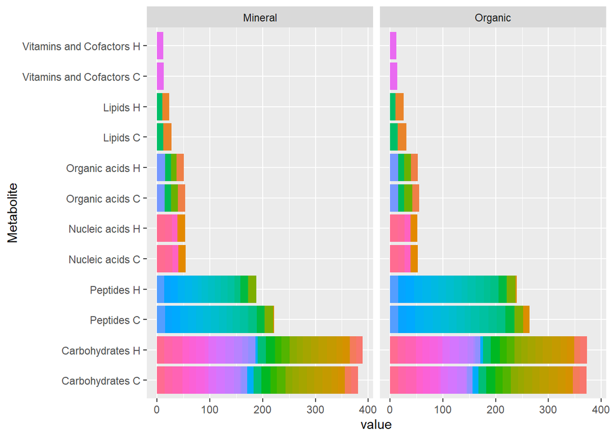

**Figure 5. Metabolite abundance by sublcass.** Carbohydrate total abundance increases in both horizons while every other subclass of metabolites decreases in both horizons.

```r
ggplot(subset(metab.clean, !is.na(Class)), aes(x, y=value,fill=Metabolite)) + geom_bar(stat="identity") + coord_flip() + theme(legend.position = "none") + facet_grid(~Horizon) + xlab("Metabolite")
```

### Carbohydrates

```r
Carbs <- figures[which(figures$Class=="Carbohydrates"),] %>% arrange(Horizon, treatment,Subclass_1, Subclass_2)
rmarkdown::paged_table(Carbs)
```

| Metabolite | Horizon | p | Class | Subclass_1 | Subclass_2 | treatment | value | x | variable |
| --- | --- | --- | --- | --- | --- | --- | --- | --- | --- |
| D-galactose | Mineral | 0.916000 | Carbohydrates | Monosaccharides | Aldoses | C | 13.676865 | Carbohydrates C | D-galactose C |
| D-glucose | Mineral | 0.244000 | Carbohydrates | Monosaccharides | Aldoses | C | 17.096152 | Carbohydrates C | D-glucose C |
| D-mannose | Mineral | 0.425000 | Carbohydrates | Monosaccharides | Aldoses | C | 13.762480 | Carbohydrates C | D-mannose C |
| D-ribose | Mineral | 0.855000 | Carbohydrates | Monosaccharides | Aldoses | C | 15.226301 | Carbohydrates C | D-ribose C |
| D-xylose | Mineral | 0.951000 | Carbohydrates | Monosaccharides | Aldoses | C | 13.266193 | Carbohydrates C | D-xylose C |
| threose | Mineral | 0.929000 | Carbohydrates | Monosaccharides | Aldoses | C | 12.684040 | Carbohydrates C | threose C |
| N-acetyl-D-mannosamine | Mineral | 0.256000 | Carbohydrates | Monosaccharides | Amino sugars | C | 14.632436 | Carbohydrates C | N-acetyl-D-mannosamine C |
| 1,3-dihydroxyacetone | Mineral | 0.400000 | Carbohydrates | Monosaccharides | Ketoses | C | 12.410730 | Carbohydrates C | 1,3-dihydroxyacetone C |
| D-gluconic acid | Mineral | 0.619000 | Carbohydrates | Monosaccharides | Sugar acids | C | 11.619578 | Carbohydrates C | D-gluconic acid C |
| glyceric acid | Mineral | 0.054000 | Carbohydrates | Monosaccharides | Sugar acids | C | 12.270662 | Carbohydrates C | glyceric acid C |

[output cut: 102 more lines]

```r
# Carbs %>% select(Metabolite, Horizon, Subclass_1, treatment, value) %>% spread(Subclass_1, value) %>% group_by(Horizon) %>% mutate(p.value = t.test(Monosaccharides, Oligosaccharides)$p.value)
Carb.M <- Carbs %>% filter(Horizon == "Mineral")
Carb.O <- Carbs %>% filter(Horizon == "Organic")
```

Sugars provide energy to microorganisms and are signaling agents for plants.<sup>12,33,34</sup> The total abundance of carbohydrates increased in a statistically negligent amount in both the organic (p=0.9779717 and mineral (p=0.7042379) horizons.<sup>3</sup>

Within the Mineral horizon, though, L-threonic acid significantly decreased (p = 0.004) while maltotriose and sophorose signficantly increased (p = 0.012 and p = 0.028). Within the Organic horizon, D-gluconic acid, glyceric acid, 1,3-dihydroxyacetone, 1,4-D-xylobiose, and D-ribose significantly decreased (p < 0.05) while melezitose significantly increased (p = 0.04).

Nearly all carbohydrates that exhibited an increase in abundance when treated with heat were oligosaccharides in both horizon, more notably in the Organic horizon (Figure 6). There was statistically significant difference between the monosaccharides and the oligosaccharides, but this trend of increased abundance of larger carbohydrates may be indicative of a shift to optimizing mineralization of recalcitrant carbons over labile carbons.<sup>35</sup>

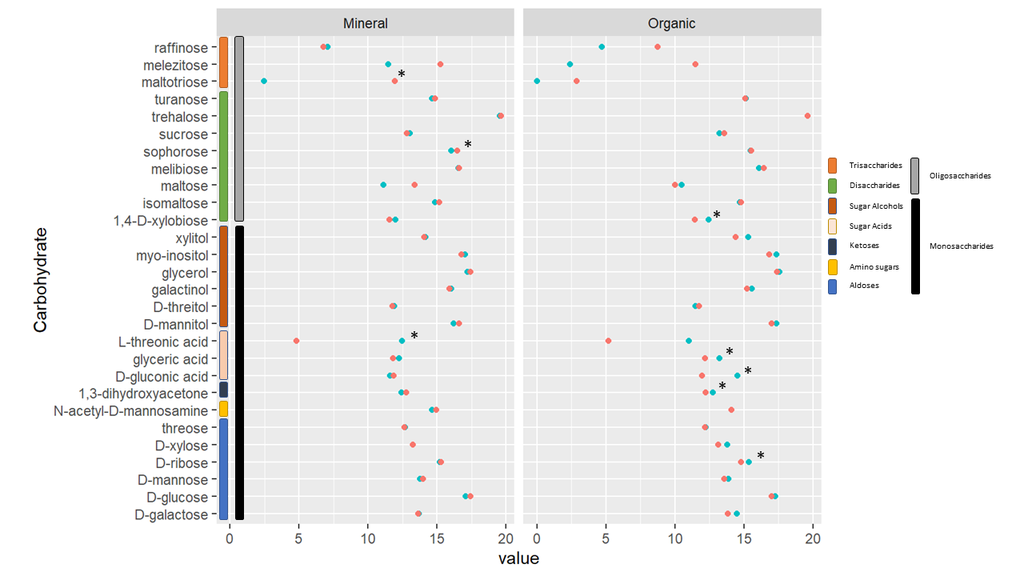

**Fig 6. Carbohydrates in Both Horizons.** 28 Carbohydrates were identified in both treatments and plotted for each horizon. Red dots indicate heat treatment while teal indicates control. Significant carbohydrates (p < 0.05) is indicated with a star.

```r
# how I made the ggplot of carbs
#ggplot(Carbs, aes(factor(Metabolite, levels=unique(Metabolite)), value, color=treatment)) + geom_point(stat="identity") +theme(legend.position = "none") + coord_flip() +facet_grid(~Horizon) + xlab("Carbohydrate") + scale_color_manual(values = c("#00BFC4","#F8766D"))
```

#### Sophorose

Sophorose, a disaccharide, is known to induce cellulase which decomposes cellulose in fungi and bacteria.<sup>36</sup> The significantly increase in abundance in the mineral horizon may be indicative of an increase in microbes that are able to decompose cellulose, a recalcitrant carbon nutrient that are less accessible than labile carbons.<sup>36</sup> Whether the soil is adapting to utilize recalcitrant carbons as a nutrient source can be tested using substrate addition studies previously described in the Harvard Forest soil.<sup>5</sup>

### Amino Acids

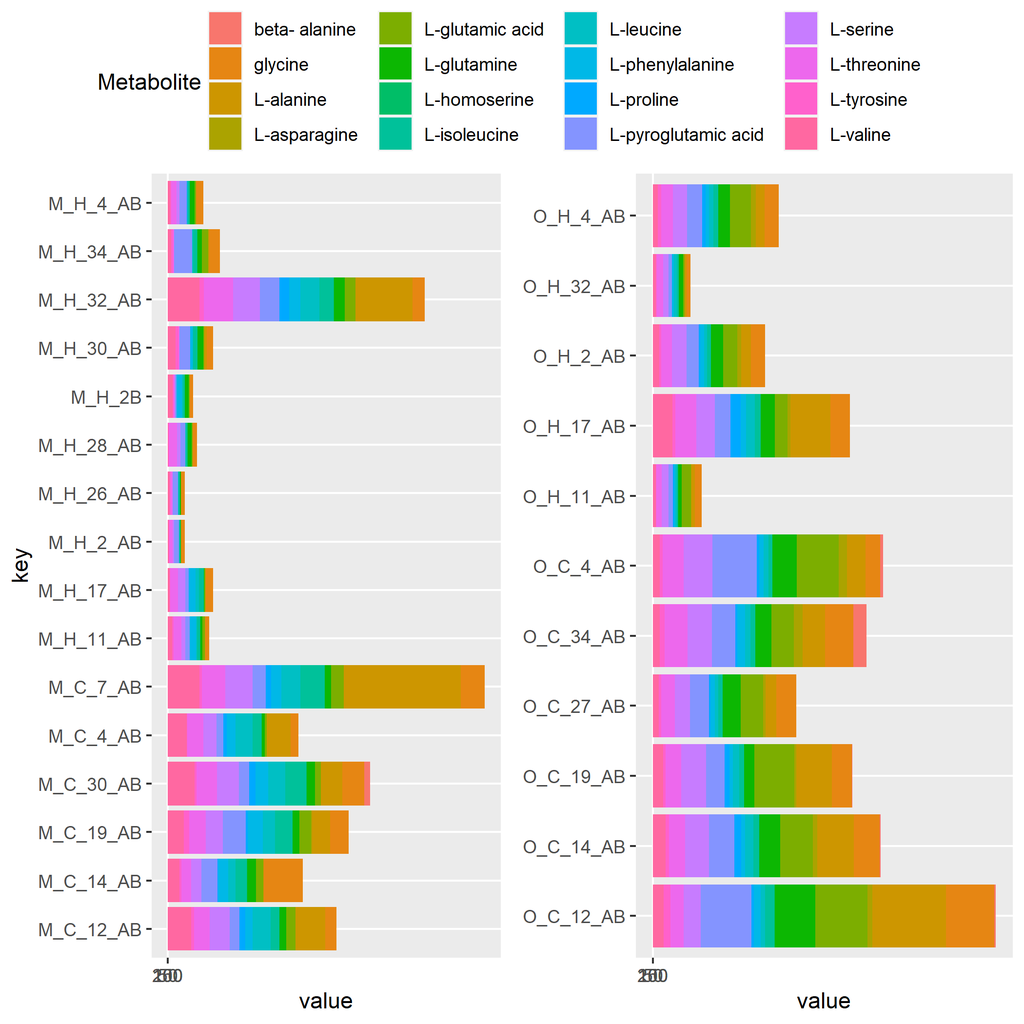

**Figure 7. Stacked barplots of 16 identified amino acids in soil plots.** Barplots indicate a depletion of overall amino acid abundance within the heat treated plots (M_H and O_H for mineral and organic horizons) compared to the control plots (M_C and O_C for mineral and organic horizons)

L-amino acids (e.g., L-Leu, L-Phe, L-Ala, L-Ile, and L-Pro) inhibit the growth of bacteria and biosynthesis of IAA, an auxin that causes plant elongation, in soil.<sup>23</sup> Of the 16 amino acids identified in the soil, 6 and 12 were statistically significant in the organic and mineral horizon, respectively. Most notably in the mineral horizon, L-leucine and L-isoleucine indicated a log2 fold change (Control/Heated) of 0.29 (p=0.0000606) and 0.16 (p=0.0000998) (Figure 9).

```r
rmarkdown::paged_table(metab.clean[which(metab.clean$Subclass_1=="Amino acids"),])
```

| Metabolite | Horizon | p | Class | Subclass_1 | Subclass_2 | treatment | value | x |
| --- | --- | --- | --- | --- | --- | --- | --- | --- |
| beta- alanine | Mineral | 3.63e-01 | Peptides | Amino acids | Other amino acids | C | 2.355567 | Peptides C |
| beta- alanine | Organic | 2.40e-02 | Peptides | Amino acids | Other amino acids | C | 11.946626 | Peptides C |
| glycine | Mineral | 3.00e-03 | Peptides | Amino acids | Common amino acids | C | 15.240558 | Peptides C |
| glycine | Organic | 3.80e-02 | Peptides | Amino acids | Common amino acids | C | 16.880375 | Peptides C |
| L-alanine | Mineral | 1.30e-02 | Peptides | Amino acids | Common amino acids | C | 15.050921 | Peptides C |
| L-alanine | Organic | 6.70e-02 | Peptides | Amino acids | Common amino acids | C | 16.995008 | Peptides C |
| L-asparagine | Mineral | 3.63e-01 | Peptides | Amino acids | Common amino acids | C | 2.085238 | Peptides C |
| L-asparagine | Organic | 3.01e-01 | Peptides | Amino acids | Common amino acids | C | 15.133593 | Peptides C |
| L-glutamic acid | Mineral | 2.00e-03 | Peptides | Amino acids | Common amino acids | C | 14.342074 | Peptides C |
| L-glutamic acid | Organic | 4.50e-02 | Peptides | Amino acids | Common amino acids | C | 17.207465 | Peptides C |

[output cut: 54 more lines]

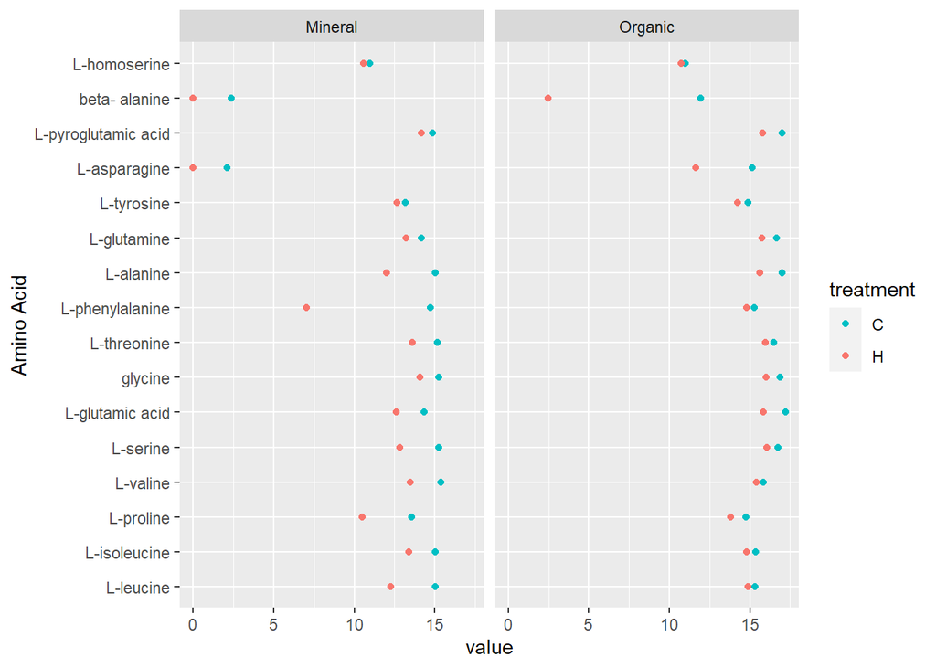

**Figure 8. Amino acid levels.** Both the Mineral and Organic horizons indicate a depletion of all amino acids.

```r
AA <- figures[which(figures$Subclass_1=="Amino acids"),] %>% arrange(Subclass_2, p)
ggplot(AA, aes(factor(Metabolite, levels=unique(Metabolite)), value, color=treatment)) + scale_color_manual(values = c("#00BFC4","#F8766D" )) + geom_point(stat="identity") + coord_flip() +facet_grid(~Horizon) + xlab("Amino Acid")
```

```r
AA.Mineral <- AA[which(AA$Horizon=="Mineral"),]
AA.M.pvalue <- t.test(AA.Mineral[which(AA.Mineral$treatment=="C"),8], AA.Mineral[which(AA.Mineral$treatment=="H"),8])$p.value
AA.O <- AA[which(AA$Horizon=="Organic"),]
AA.O.pvalue <- t.test(AA.O[which(AA.O$treatment=="C"),8], AA.O[which(AA.O$treatment=="H"),8])$p.value
```

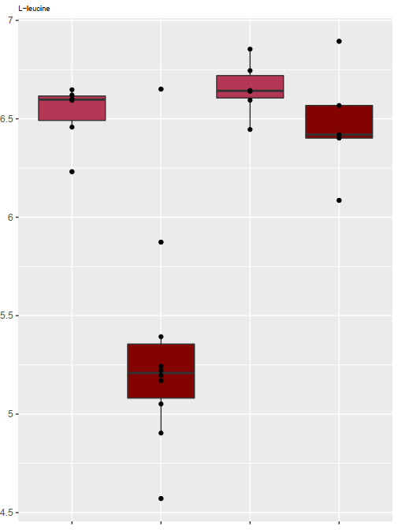

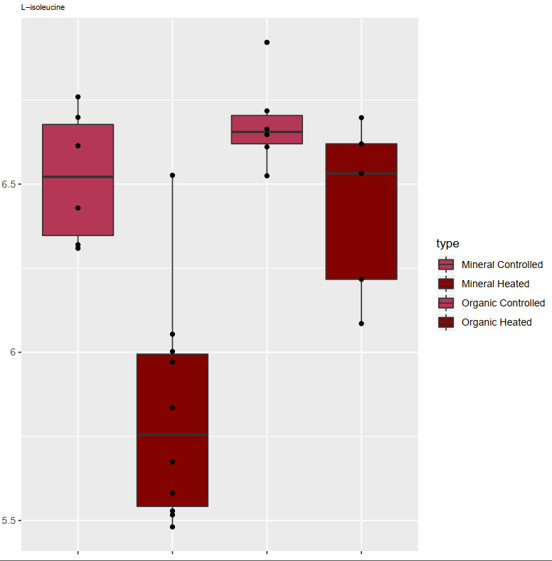

**Figure 9. L-leucine and L-isoleucine.** Data indicates L-leucine and L-isoleucine are depleted in the both horizons with heat treatment. Statistical significance was exhibited in the (left 2 boxplots) mineral horizon (p-values = 0.0000606 and 0.0000998, respectively).

```r
include_graphics(c("Figures/L-leucine.png", "Figures/L-isoleucine.PNG"))
```

### Organic Acids

3 of the 4 identified organic acids were significantly depleted in the Organic horizon: Glycolic acid, Fumaric acid, and 3-hydroxybutyric acid (Figure 10). Low levels of organic acids in soil sample analysis is typical and has been assumed to be due to the high degree of buffering by the soil’s solid phase.<sup>40</sup> Thus, it is difficult to conclude whether the significant depletion of organic acids in our sample is statistically sound. Nonetheless, this depletion of organic acids may be indicative of a significant effect on the rhizosphere and plant-soil dynamics as replenishment of organic acid levels is highly reliant on plants and animals.<sup>40</sup>

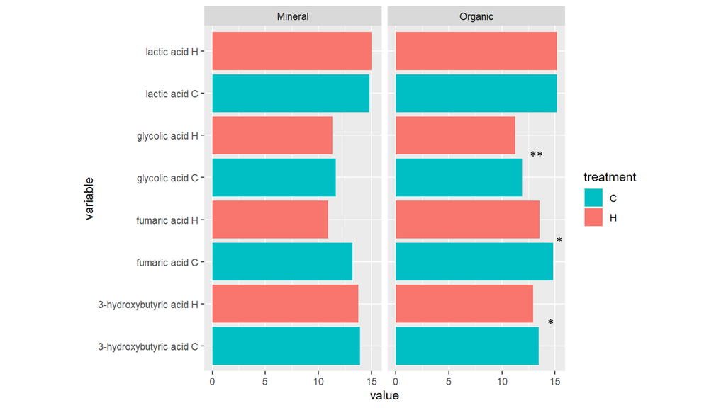

**Figure 10. Organic acid abundance.** Glycolic acid (** p < 0.01), Fumaric acid, and 3-hydroxybutyric acid were significantly (p < 0.05) were significantly depleted.

```r
OA <- figures[which(figures$Class=="Organic acids"),]
# how i made figure 10
#ggplot(OA, aes(x=variable, y=value, fill=treatment)) + geom_bar(stat="identity") + facet_grid(~Horizon) + coord_flip()  + scale_fill_manual(values = c("#00BFC4","#F8766D"))
OA.M <- OA[which(OA$Horizon=="Mineral"),]
OA.M.pvalue <- t.test(OA.M[which(OA.M$treatment=="C"),8], OA.M[which(OA.M$treatment=="H"),8])$p.value
OA.O <- OA[which(OA$Horizon=="Organic"),]
OA.O.pvalue <- t.test(OA.O[which(OA.O$treatment=="C"),8], OA.O[which(OA.O$treatment=="H"),8])$p.value
```

### Lipids from GC-MS

Inositol phosphate, commonly extracted from plant seeds to store phosphate and never from bacteria.<sup>41</sup> 4-aminobutyric acid (GABA) accumulates in plants as well due to biotic and abiotic stress,<sup>42</sup> so the findings of Inositol phosphate and GABA in our samples is most likely from plants.

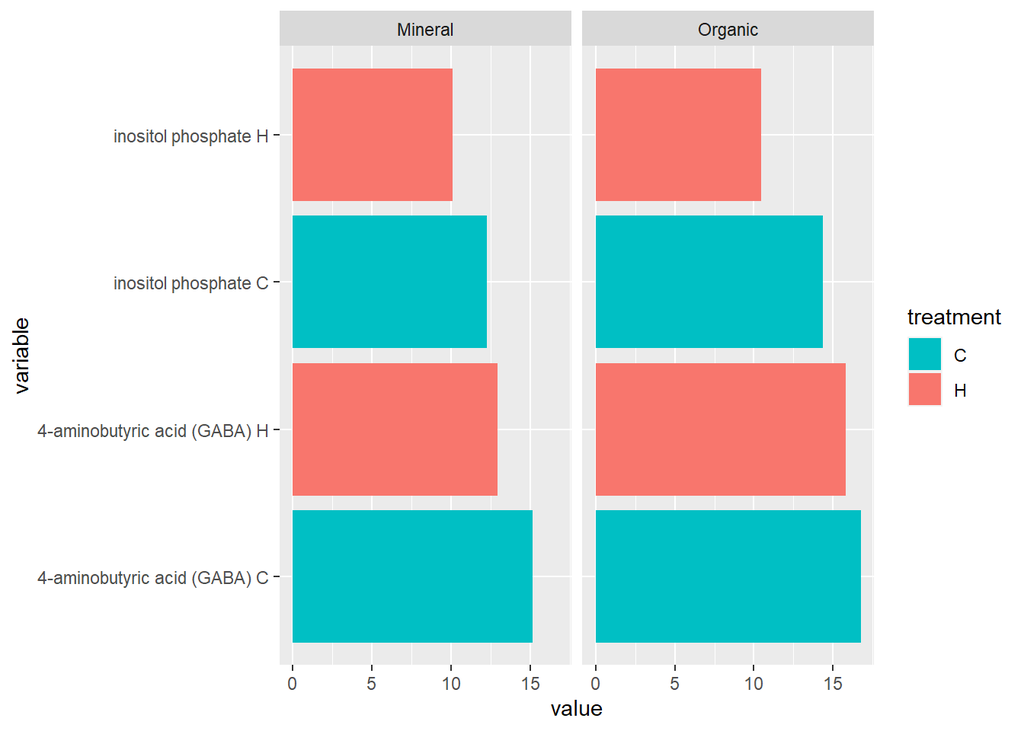

```r
ggplot(figures[which(figures$Class=="Lipids"),], aes(x=variable, y=value, fill=treatment)) + geom_bar(stat="identity") + facet_grid(~Horizon) + coord_flip() + scale_fill_manual(values = c("#00BFC4","#F8766D"))
```

## Lipids

The most striking evidence of a transformation of carbon from the organic horizon to the mineral horizon<sup>3</sup> is the depletion of lipids in every class in the organic horizon along with the increase of lipid abundance in every class in the mineral horizon (Figure 13).

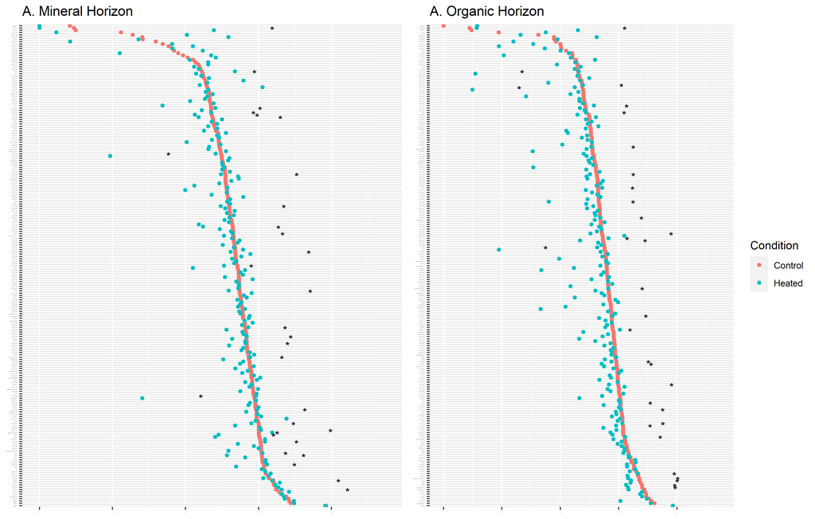

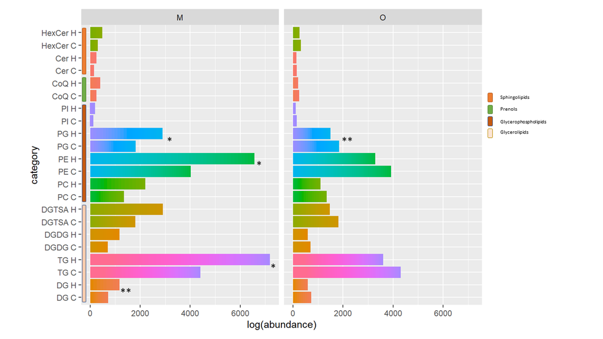

**Figure 13. Logged lipid abundance by subclass.** The Sphingolipids, Prenols, Glycerophospholipids, and Glycerolipids are representated by Class and subclass. Unique lipids are represented by individual colors within the bars represented by subclass. Abundance was not normalized or standardized for this figure.

```r
Lipid.clean <- Lipids %>% gather(plot, abundance, Blanch_Nat_Lip_C_12_AB_M_17_POS:Blanch_Nat_Lip_H_4_AB_M_05_POS)  %>%
  mutate(Treatment = gsub("[^CH]+", "", plot)) %>%
  mutate(Plot.name = plot) %>%
  separate(plot, c("A","B", "C", "D", "E", "F", "Horizon", "H", "I")) %>%
  select(-A, -B,-C,-D,-E,-F,-H,-I) %>%
  mutate(Horizon = gsub("02", "M", Horizon)) %>%
  mutate(category = paste(Subclass, Treatment)) %>%
  mutate(category = fct_relevel(category, "CoQ C", "CoQ H","Cer C", "Cer H", "HexCer C", "HexCer H", "PC C", "PC H", "PE C", "PE H", "PG C", "PG H", "PI C", "PI H", "DG C", "DG H", "TG C", "TG H", "DGDG C", "DGDG H", "DGTSA C", "DGTSA H"))
# How I made figure 13
#ggplot(Lipid.clean, aes(x=category, y=log(abundance), fill=row.identity)) + geom_bar(stat="identity") + theme(legend.position="none") + coord_flip() +facet_grid(~Horizon)
```

### Sphingolipids

Sphingolipids significantly decreased in the Organic horizon and increased in the Mineral horizon (p = 0.002, p = 0.044). Sphingolipids are a class of lipids characterized by a long- chain amino alcohol sphingoid backbone with an amide- bound fatty acyl chain.<sup>44</sup> Bacteria that contain sphingolipids are: Bacteriodetes, Chlorobi, and Alphaproteobacteria. According to the associated metatranscriptomic data for these soil samples, Alphaproteobacteria were affiliated with the majority of the metabolic pathways with significant treatment effect.<sup>3</sup> Increased levels of Sphingolipids in the mineral horizon support notions that Alphaproteobacteria are active contributors to the metabolic activity within the heated soil.

### Prenols

3 prenols, Coenzyme 8, 9, and 10 (CoQ8, CoQ9, CoQ10), also known as ubiquinones, were identified in the soil samples. Ubiquinones function as electron transporters in the electron transport chain of oxygen photosynthesis and the aerobic respiratory chain.<sup>45</sup> None were significantly altered in either horizon, which is possibly contradictory to the correlation of cell respiration in soil with heat treatment<sup>35,46,47</sup> and supports the importance of biophysical factors beyond just temperature in controlling soil respiration.<sup>35</sup> Nonetheless, the lack of changes may also be due to small sample size, a limitation that should be taken into account.

### Glycerophospholipids

There was trend of depletion in the organic horizon as well as an increase in abundance of glycerophosphoilipids in the mineral horizon (Figure 13). In fact, glycerophosphoglycerols (PG) was significantly altered in both horizons in this manner (p < 0.05). Glycerophosphoethanolamines (PE) abundance significantly increased in the mineral horizon as well. Glycerophospholipids make up cell membranes and are the prevalent lipids in non-photosynthetic organisms.<sup>48,49</sup> The significant increase in the mineral horizon supports the FTICR-MS analysis of carbon transformation.<sup>3</sup>

### Glycerolipids

Glycerolipids are storage fats with triacylglycerols and diacylglycerols typically being the most abundant subclasses in the soil.<sup>50</sup> Interestingly, triacylglycerols, and diacylglycerols were signficantly increased in the mineral horizon (p = 0.03 and p = 0.0095). This strongly supports the transformation of the carbons reported by the associated FTICR-MS analysis.<sup>3</sup>

# Conclusion

Though GC-MS and LC tandem MS are of the most accurate and comprehensive tools for metabolomic and lipidomic extraction and analysis, there is much more technological and analytical advancements needed to fully understand the biochemical make-up of this extremely inaccessible microenviornment. Nonetheless, the successful identification of 211 unique metabolites (71 of which were matched to KEGG) and 192 unique lipids provides a novel metabolite profile to terrestrial soil and attests to the growing field of metabolomics in soil biology.

# References

1. O’Neill BC, Tebaldi C, Vuuren DP van, et al. The Scenario Model Intercomparison Project (ScenarioMIP) for CMIP6. *Geoscientific Model Development*. 2016;9(9):3461-3482. doi:10.5194/gmd-9-3461-2016

2. Classen AT, Sundqvist MK, Henning JA, et al. Direct and indirect effects of climate change on soil microbial and soil microbial-plant interactions: What lies ahead? *Ecosphere*. 2015;6(8):art130. doi:https://doi.org/10.1890/ES15-00217.1

3. Rodriguez-Reillo W, Alteio L, Bailey V, et al. Long-term Warming of Terrestrial Soil Leads to Microbial Carbohydrate and Lignin Transformation. Published online 2021.

4. Melillo JM, Butler S, Johnson J, et al. Soil warming, carbon–nitrogen interactions, and forest carbon budgets. *Proceedings of the National Academy of Sciences*. 2011;108(23):9508-9512. doi:10.1073/pnas.1018189108

5. DeAngelis KM, Pold G, Topçuoğlu BD, et al. Long-term forest soil warming alters microbial communities in temperate forest soils. *Frontiers in Microbiology*. 2015;6. doi:10.3389/fmicb.2015.00104

6. Burton AJ, Melillo JM, Frey SD. Adjustment of forest ecosystem root respiration as temperature warms. *Journal of Integrative Plant Biology*. 2008;50(11):1467-1483. doi:10.1111/j.1744-7909.2008.00750.x

7. Li J, Wang G, Mayes MA, et al. Reduced carbon use efficiency and increased microbial turnover with soil warming. *Global Change Biology*. 2019;25(3):900-910. doi:10.1111/gcb.14517

8. W. Irvine G, Nguyen S. An overview of the “-omics” fields at the forefront of next-generation personalized medicine and fundamental systems biology studies. *Biomedical Genetics and Genomics*. 2019;4(2). doi:10.15761/BGG.1000147

9. Nicora CD, Burnum-Johnson KE, Nakayasu ES, et al. The MPLEx Protocol for Multi-omic Analyses of Soil Samples. *Journal of Visualized Experiments : JoVE*. 2018;(135). doi:10.3791/57343

10. Larras F, Billoir E, Scholz S, et al. A multi-omics concentration-response framework uncovers novel understanding of triclosan effects in the chlorophyte Scenedesmus vacuolatus. *Journal of Hazardous Materials*. 2020;397:122727. doi:10.1016/j.jhazmat.2020.122727

11. Jaiswal S, Kumar M, Mandeep null, Sunita null, Singh Y, Shukla P. Systems Biology Approaches for Therapeutics Development Against COVID-19. *Frontiers in Cellular and Infection Microbiology*. 2020;10:560240. doi:10.3389/fcimb.2020.560240

12. Miller SB, Heuberger AL, Broeckling CD, Jahn CE. Non-Targeted Metabolomics Reveals Sorghum Rhizosphere-Associated Exudates are Influenced by the Belowground Interaction of Substrate and Sorghum Genotype. *International Journal of Molecular Sciences*. 2019;20(2). doi:10.3390/ijms20020431

13. Swenson TL, Karaoz U, Swenson JM, Bowen BP, Northen TR. Linking soil biology and chemistry in biological soil crust using isolate exometabolomics. *Nature Communications*. 2018;9(1):19. doi:10.1038/s41467-017-02356-9

14. Llorens E, Camañes G, Lapeña L, García-Agustín P. Priming by Hexanoic Acid Induce Activation of Mevalonic and Linolenic Pathways and Promotes the Emission of Plant Volatiles. *Frontiers in Plant Science*. 2016;7:495. doi:10.3389/fpls.2016.00495

15. Fernandez O, Urrutia M, Berton T, et al. Metabolomic characterization of sunflower leaf allows discriminating genotype groups or stress levels with a minimal set of metabolic markers. *Metabolomics: Official Journal of the Metabolomic Society*. 2019;15(4):56. doi:10.1007/s11306-019-1515-4

16. Oromi N, Jové M, Pascual-Pons M, et al. Differential metabolic profiles associated to movement behaviour of stream-resident brown trout (Salmo trutta). *PloS One*. 2017;12(7):e0181697. doi:10.1371/journal.pone.0181697

17. Behr JH, Bouchereau A, Berardocco S, Seal CE, Flowers TJ, Zörb C. Metabolic and physiological adjustment of Suaeda maritima to combined salinity and hypoxia. *Annals of Botany*. 2017;119(6):965-976. doi:10.1093/aob/mcw282

18. Chaparro JM, Holm DG, Broeckling CD, Prenni JE, Heuberger AL. Metabolomics and Ionomics of Potato Tuber Reveals an Influence of Cultivar and Market Class on Human Nutrients and Bioactive Compounds. *Frontiers in Nutrition*. 2018;5:36. doi:10.3389/fnut.2018.00036

19. Mhlongo MI, Piater LA, Steenkamp PA, Labuschagne N, Dubery IA. Concurrent Metabolic Profiling and Quantification of Aromatic Amino Acids and Phytohormones in Solanum lycopersicum Plants Responding to Phytophthora capsici. *Metabolites*. 2020;10(11). doi:10.3390/metabo10110466

20. Pahalagedara ASNW, Flint S, Palmer J, Subbaraj A, Brightwell G, Gupta TB. Antimicrobial Activity of Soil Clostridium Enriched Conditioned Media Against Bacillus mycoides, Bacillus cereus, and Pseudomonas aeruginosa. *Frontiers in Microbiology*. 2020;11:608998. doi:10.3389/fmicb.2020.608998

21. Tugizimana F, Steenkamp PA, Piater LA, Labuschagne N, Dubery IA. Unravelling the Metabolic Reconfiguration of the Post-Challenge Primed State in Sorghum bicolor Responding to Colletotrichum sublineolum Infection. *Metabolites*. 2019;9(10). doi:10.3390/metabo9100194

22. Sun L, Cao X, Tan C, et al. Analysis of the effect of cadmium stress on root exudates of Sedum plumbizincicola based on metabolomics. *Ecotoxicology and Environmental Safety*. 2020;205:111152. doi:10.1016/j.ecoenv.2020.111152

23. Wang Y, Zhu S, Liu T, Guo B, Li F, Bai X. Identification of the rhizospheric microbe and metabolites that led by the continuous cropping of ramie (Boehmeria nivea L. Gaud). *Scientific Reports*. 2020;10(1):20408. doi:10.1038/s41598-020-77475-3

24. Ziegler J, Schmidt S, Chutia R, et al. Non-targeted profiling of semi-polar metabolites in Arabidopsis root exudates uncovers a role for coumarin secretion and lignification during the local response to phosphate limitation. *Journal of Experimental Botany*. 2016;67(5):1421-1432. doi:10.1093/jxb/erv539

25. Zárate R, El Jaber-Vazdekis N, Tejera N, Pérez JA, Rodríguez C. Significance of long chain polyunsaturated fatty acids in human health. *Clinical and Translational Medicine*. 2017;6(1):25. doi:10.1186/s40169-017-0153-6

26. Wang T, Nie S, Ma G, et al. Quantitative lipidomic analysis of Ascaris suum. *PLoS neglected tropical diseases*. 2020;14(12):e0008848. doi:10.1371/journal.pntd.0008848

27. Pham TH, Zaeem M, Fillier TA, et al. Targeting Modified Lipids during Routine Lipidomics Analysis using HILIC and C30 Reverse Phase Liquid Chromatography coupled to Mass Spectrometry. *Scientific Reports*. 2019;9(1):5048. doi:10.1038/s41598-019-41556-9

28. Fahy E, Cotter D, Sud M, Subramaniam S. Lipid classification, structures and tools. *Biochimica et biophysica acta*. 2011;1811(11):637-647. doi:10.1016/j.bbalip.2011.06.009

29. Hiller K, Hangebrauk J, Jäger C, Spura J, Schreiber K, Schomburg D. MetaboliteDetector: Comprehensive analysis tool for targeted and nontargeted GC/MS based metabolome analysis. *Analytical Chemistry*. 2009;81(9):3429-3439. doi:10.1021/ac802689c

30. Kyle JE, Stratton KG, Zink EM, et al. A resource of lipidomics and metabolomics data from individuals with undiagnosed diseases. *Scientific Data*. 2021;8(1):114. doi:10.1038/s41597-021-00894-y

31. Kanehisa M. KEGG: Kyoto encyclopedia of genes and genomes - PubMed. Published online January 2000. Accessed April 28, 2021. https://pubmed.ncbi.nlm.nih.gov/10592173/

32. Yang Y, Pollard AM, Höfler C, et al. Relation between chemotaxis and consumption of amino acids in bacteria. *Molecular Microbiology*. 2015;96(6):1272-1282. doi:https://doi.org/10.1111/mmi.13006

33. Behera B, Wagner GH. Microbial Growth Rate in Glucose-Amended Soil. *Soil Science Society of America Journal*. 1974;38(4):591-594. doi:https://doi.org/10.2136/sssaj1974.03615995003800040021x

34. Trouvelot S, Héloir M-C, Poinssot B, et al. Carbohydrates in plant immunity and plant protection: Roles and potential application as foliar sprays. *Frontiers in Plant Science*. 2014;5. doi:10.3389/fpls.2014.00592

35. Zhang Q, Phillips RP, Manzoni S, et al. Changes in photosynthesis and soil moisture drive the seasonal soil respiration-temperature hysteresis relationship. *Agricultural and Forest Meteorology*. 2018;259:184-195. doi:10.1016/j.agrformet.2018.05.005

36. Behera BC, Sethi BK, Mishra RR, Dutta SK, Thatoi HN. Microbial cellulases – Diversity & biotechnology with reference to mangrove environment: A review. *Journal of Genetic Engineering & Biotechnology*. 2017;15(1):197-210. doi:10.1016/j.jgeb.2016.12.001

37. Reina-Bueno M, Argandoña M, Nieto JJ, et al. Role of trehalose in heat and desiccation tolerance in the soil bacterium Rhizobium etli. *BMC Microbiology*. 2012;12(1):207. doi:10.1186/1471-2180-12-207

38. Zhang Q, Yan T. Correlation of Intracellular Trehalose Concentration with Desiccation Resistance of Soil Escherichia coli Populations Applied and Environmental Microbiology. Published online September 2012. Accessed April 29, 2021. https://aem.asm.org/content/78/20/7407

39. Paungfoo-Lonhienne C, Lonhienne TGA, Rentsch D, et al. Plants can use protein as a nitrogen source without assistance from other organisms. *Proceedings of the National Academy of Sciences*. 2008;105(11):4524-4529. doi:10.1073/pnas.0712078105

40. Adeleke R, Nwangburuka C, Oboirien B. Origins, roles and fate of organic acids in soils: A review. *South African Journal of Botany*. 2017;108:393-406. doi:10.1016/j.sajb.2016.09.002

41. Roberts MF. Inositol in Bacteria and Archaea. In: Majumder AL, Biswas BB, eds. *Biology of Inositols and Phosphoinositides*. Vol 39. Springer US; 2006:103-133. doi:10.1007/0-387-27600-9_5

42. Ramesh SA, Tyerman SD, Xu B, et al. GABA signalling modulates plant growth by directly regulating the activity of plant-specific anion transporters. *Nature Communications*. 2015;6(1):7879. doi:10.1038/ncomms8879

43. Zheng G, Tian B, Zhang F, Tao F, Li W. Plant adaptation to frequent alterations between high and low temperatures: Remodeling of membrane lipids and maintenance of unsaturation levels. *Plant, cell & environment*. 2011;34(9):1431-1442. doi:10.1111/j.1365-3040.2011.02341.x

44. Heaver SL, Johnson EL, Ley RE. Sphingolipids in host–microbial interactions. *Current Opinion in Microbiology*. 2018;43:92-99. doi:10.1016/j.mib.2017.12.011

45. Liu M, Lu S. Plastoquinone and Ubiquinone in Plants: Biosynthesis, Physiological Function and Metabolic Engineering. *Frontiers in Plant Science*. 2016;7. doi:10.3389/fpls.2016.01898

46. Giasson M-A, Ellison AM, Bowden RD, et al. Soil respiration in a northeastern US temperate forest: A 22-year synthesis. *Ecosphere*. 2013;4(11):art140. doi:10.1890/ES13.00183.1

47. Micks P, Aber JD, Boone RD, Davidson EA. Short-term soil respiration and nitrogen immobilization response to nitrogen applications in control and nitrogen-enriched temperate forests. *Forest Ecology and Management*. 2004;196(1):57-70. doi:10.1016/j.foreco.2004.03.012

48. Tao BY. Chapter 24 - Industrial Applications for Plant Oils and Lipids. In: Yang S-T, ed. *Bioprocessing for Value-Added Products from Renewable Resources*. Elsevier; 2007:611-627. doi:10.1016/B978-044452114-9/50025-6

49. Riekhof WR, Benning C. Chapter 2 - Glycerolipid Biosynthesis. In: Harris EH, Stern DB, Witman GB, eds. *The Chlamydomonas Sourcebook (Second Edition)*. Academic Press; 2009:41-68. doi:10.1016/B978-0-12-370873-1.00010-1

50. Bittman R. Glycerolipids: Chemistry. In: Roberts GCK, ed. *Encyclopedia of Biophysics*. Springer; 2013:907-914. doi:10.1007/978-3-642-16712-6_527

# Acknowledgements

I would like to thank Dr. Jeffrey Blanchard, our Principle Investigator. Thank you for your support, guidance, and the life lessons that have made me a better researcher and life-long learner. I would also like to thank Nathan Haywood and William Rodriguez-Reillo for their collaboration and insight. Thank you committee board member, Dr. Moscarella, for always pushing me and Biology Advisor, Dr. Byers, for your investment in my education, and the laboratory team within the Blanchard Lab for their inspirational work. Additionally, I’d like to thank the contributors of the working manuscript: Lauren Alteio, Vanessa Bailey, Lisa Bramer, Stephen Callister, Rosalie K Chu, Serita Frey, Marco Keiluweit, Young-Mo Kim, Jennifer Kyle, Jerry Melillo, Jim Tang, Malak Tfaily. Thank you friends and family who push me to be a better person; I am who I am because of you.

**Supplementary Material**